# Mid-Term Decision

```r
pacman::p_load(readr, haven, readxl, downloader, tidyverse, ggbeeswarm, mosaic, stringr, pander, DT, ggplot2, alr3, foreign, measurements)
```

```r
# NA = 0 in the gradebook
# Can make quantitative data into T/F statements
Midterm <- read.csv("../../Data/MidtermVsFinalGrades2.csv")

#View(Midterm)
```

```r
########## Cleaned data and created columns with people around me ####################
########## Found mutate_all here (https://stackoverflow.com/questions/19379081/how-to-replace-na-values-in-a-table-for-selected-columns) ######################

Midterm2 <- Midterm %>%
  mutate_all(~replace_na(., 0)) %>%
  mutate(Analyses86 = ifelse(AnalysesTheory > 86, 1, 0),
#         AssesActual66 = ifelse(AssessmentQuizActual > 66, 1, 0),
#         Mid76 = ifelse(Midterm == 76, 1, 0),
         Mid72_80 = ifelse(Midterm >= 72 & Midterm < 80, 1, 0),
         Overall = round(Midterm*.06 + FinalExam*.14 + AssessmentQuizCompletion*.05 + AssessmentQuizActual*0 + AnalysesTheory*.3 + PeerReviews*.1 + ClassActivities*.1 + SkillQuizzes*.1 + 100*.15, digits = 2)) %>%
  mutate(Grade = as.factor(case_when(
    Overall >= 93 ~ "A",
    Overall >= 90 & Overall < 93 ~ "A-",
    Overall >= 87 & Overall < 90 ~ "B+",
    Overall >= 83 & Overall < 87 ~ "B",
    Overall >= 80 & Overall < 83 ~ "B-",
    Overall >= 77 & Overall < 80 ~ "C+",
    Overall >= 73 & Overall < 77 ~ "C",
    Overall >= 70 & Overall < 73 ~ "C-",
    Overall >= 67 & Overall < 70 ~ "D+",
    Overall >= 63 & Overall < 67 ~ "D",
    Overall >= 60 & Overall < 63 ~ "D-",
    Overall > 0 & Overall < 60 ~ "F")),
         Grade.group = as.factor(case_when(
    Overall >= 90 ~ "A",
    Overall >= 80 & Overall < 90 ~ "B",
    Overall >= 70 & Overall < 80 ~ "C",
    Overall >= 60 & Overall < 70 ~ "D",
    Overall > 0 & Overall < 60 ~ "F")))

########### Removed all the people who didn't take the Midterm #######################

Midterm_0_removed <- Midterm2[c(-3, -8, -26, -38, -53, -42), ]
# 3 0% Midterm. Didn't take midterm. Everything else seems okay.
# 8 0% Midterm. Seems to have given a half-hearted effort.
# 26 0% Midterm. 67% on Theories and 52% on Final.
# 38 0% everything. Withdrawn?
# 42 Removed as person appears to have given up after the midterm?
# 53 0% on Mid/Final. Half-hearted effort rest of semester.


# Need to replace NA with zeros.
# View(Midterm2)
# View(Midterm_0_removed)
```

**Comments to Critiquers**

1. How do I reorder the levels of the `Grade` and `Grade.group` columns since there are +, -, and the letter e is missing?
2. Don’t I want to base this entire analysis off of my midterm score? My `Overall` column seems to be a better option to use than `Midterm`, but I won’t know my `Overall` score til the end of the semester. . . What do I do?
3. Do I remove people that are messing with the data?

**Corrections I made**

1. I added my Midterm score to the Summary section. (Saunders)

## Background

I received a 76 out of 100 on my midterm. I get to determine whether I will keep or drop my mid-term score as it makes up 30% of the 20% that my Midterm and Final scores count toward my final grade.

## What You’d Like

### Summary

```r
Mid10.a.lm <- lm(FinalExam ~ Midterm + ClassActivities, data = Midterm2)
predict(Mid10.a.lm, data.frame(Midterm = 76, ClassActivities = 100), interval = "prediction")
```

[output not shown]

I am going to keep my midterm score of 76. My final exam score is projected to be a 72 with the ability of me scoring between 39 and 100.

Just for kicks here is the prediction from Attempt 8:

```r
mid3 <- Midterm2[c(-38, -2), ]

Mid8.lm <- lm(FinalExam ~ Midterm + AnalysesTheory + SkillQuizzes + Overall, data = mid3)
pander(summary(Mid8.lm))
```

|  | Estimate | Std. Error | t value | Pr(>\|t\|) |
| --- | --- | --- | --- | --- |
| **(Intercept)** | -165.1 | 13.51 | -12.22 | 2.387e-16 |
| **Midterm** | -0.2423 | 0.06659 | -3.638 | 0.0006697 |
| **AnalysesTheory** | -2.087 | 0.1755 | -11.89 | 6.482e-16 |
| **SkillQuizzes** | -0.4726 | 0.083 | -5.694 | 7.338e-07 |
| **Overall** | 5.358 | 0.3938 | 13.61 | 4.302e-18 |

Fitting linear model: FinalExam ~ Midterm + AnalysesTheory + SkillQuizzes + Overall

| Observations | Residual Std. Error | $R^2$ | Adjusted $R^2$ |
| --- | --- | --- | --- |
| 53 | 8.065 | 0.8679 | 0.8569 |

```r
predict(Mid8.lm, data.frame(Midterm = 76, AnalysesTheory = 93, SkillQuizzes = 100, Overall = 90), interval = "prediction")
```

```
##        fit      lwr      upr
## 1 57.38311 40.71697 74.04925
```

With a 76 for my final, 14 out of 15 on my Analyses and Theories, get 100% on my Skill Quizzes, and hypothetically earn that A- I’m aiming for, I will receive a 57 on the Final. When playing around with the prediction function, I think it’s because there’s an expectation from that `Overall` column that if I did well with my Analyses and SkillQuizzes I should have received a higher `Final` score than I’m projecting for myself. I actually think it can be put this way: If I received a 90 in the course then it is expected that I should have received a Final exam score of the following if I completed everything in the course 100%:

```r
predict(Mid8.lm, data.frame(Midterm = 76, AnalysesTheory = 100, SkillQuizzes = 100, Overall = 90), interval = "prediction")
```

```
##        fit      lwr      upr
## 1 42.77562 25.51962 60.03161
```

```r
predict(Mid8.lm, data.frame(Midterm = 76, AnalysesTheory = 80, SkillQuizzes = 100, Overall = 90), interval = "prediction")
```

```
##        fit      lwr      upr
## 1 84.51131 67.98955 101.0331
```

### Analysis

#### Attempt 1

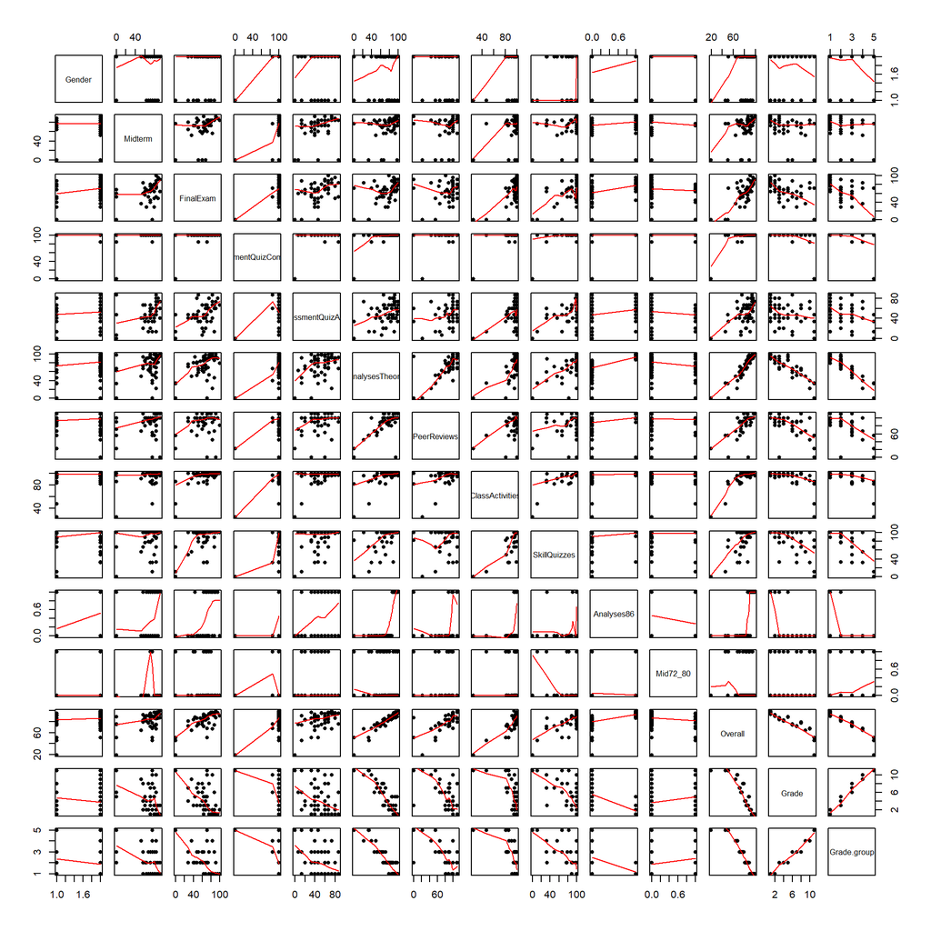

```r
pairs(Midterm2, panel = panel.smooth, pch = 16, cex = 0.8, col = "black")
```

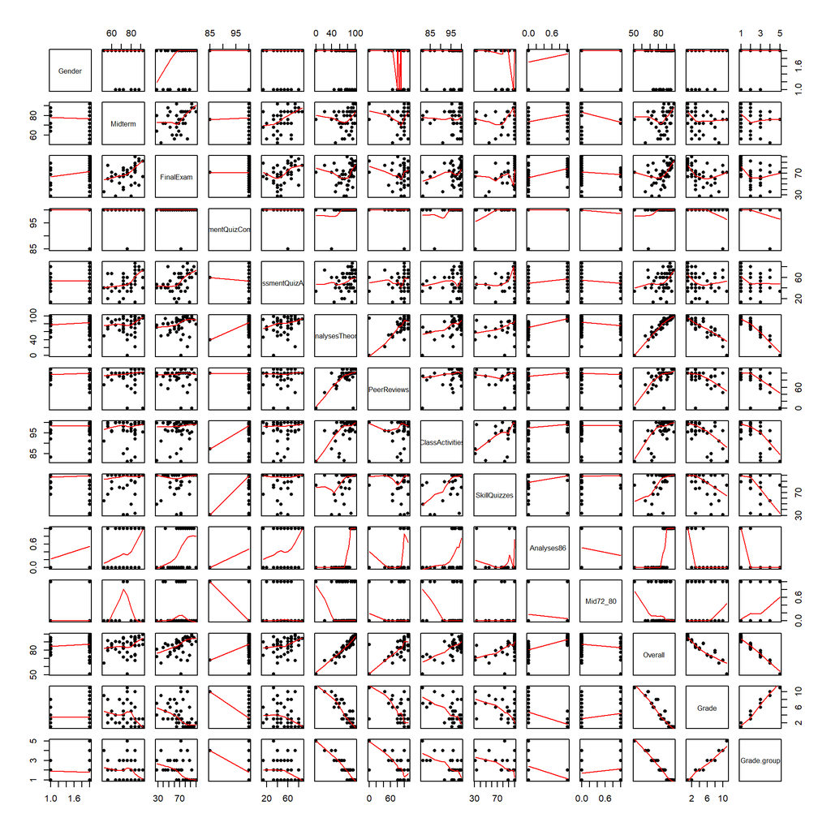

```r
pairs(Midterm_0_removed, panel = panel.smooth, pch = 16, cex = 0.8, col = "black")
```

Added columns `Analyses86`, `Mid72_80`, `Overall`, `Grade`, and `Grade.group`.

1. `Analyses86`: Those who got 13 out of 15.
2. `Mid72_80`: Those who scored similarly to me.
3. `Overall`: Overall course final grade. *Since no regression battleship column was available, everyone got a 100% to calculate this.*
4. `Grade`: Letter grade (11 levels)
5. `Grade.group`: Groupings of letter grades (5 levels)

I’m not sure if it’s better to remove these observations or not. Here is what I see:

- 3 - 0% Midterm. Didn’t take midterm. Everything else seems okay.
- 8 - 0% Midterm. Seems to have given a half-hearted effort.
- 26 - 0% Midterm. 67% on Theories and 52% on Final.
- 38 - 0% everything. Withdrawn?
- 42 - Person appears to have given up after the midterm?
- 53 - 0% on Mid/Final. Half-hearted effort rest of semester.

I believe `Midterm` and `Overall` will be the best ones to use. But can I use overall since I don’t know what my final grade might be? Don’t I want to base this off of my midterm score?

#### Attempt 2

```r
Mid.lm <- lm(FinalExam ~ Midterm, data = Midterm2)
pander(summary(Mid.lm))
```

|  | Estimate | Std. Error | t value | Pr(>\|t\|) |
| --- | --- | --- | --- | --- |
| **(Intercept)** | 31.9 | 8.253 | 3.865 | 0.000305 |
| **Midterm** | 0.4805 | 0.1123 | 4.28 | 7.865e-05 |

Fitting linear model: FinalExam ~ Midterm

| Observations | Residual Std. Error | $R^2$ | Adjusted $R^2$ |
| --- | --- | --- | --- |
| 55 | 20.04 | 0.2569 | 0.2428 |

```r
Mid.rem.lm <- lm(FinalExam ~ Midterm, data = Midterm_0_removed)
pander(summary(Mid.rem.lm))
```

|  | Estimate | Std. Error | t value | Pr(>\|t\|) |
| --- | --- | --- | --- | --- |
| **(Intercept)** | 10.76 | 16.59 | 0.6485 | 0.5198 |
| **Midterm** | 0.77 | 0.2151 | 3.579 | 0.000814 |

Fitting linear model: FinalExam ~ Midterm

| Observations | Residual Std. Error | $R^2$ | Adjusted $R^2$ |
| --- | --- | --- | --- |
| 49 | 15.69 | 0.2141 | 0.1974 |

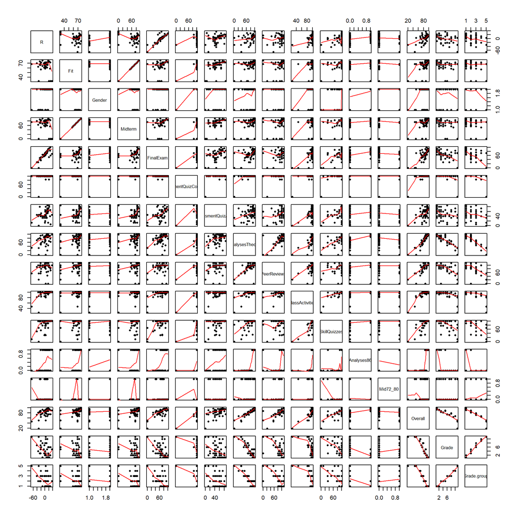

```r
pairs(cbind(R = Mid.lm$res, Fit = Mid.lm$fit, Midterm2), panel = panel.smooth, pch=16, cex=0.7, col="black")
```

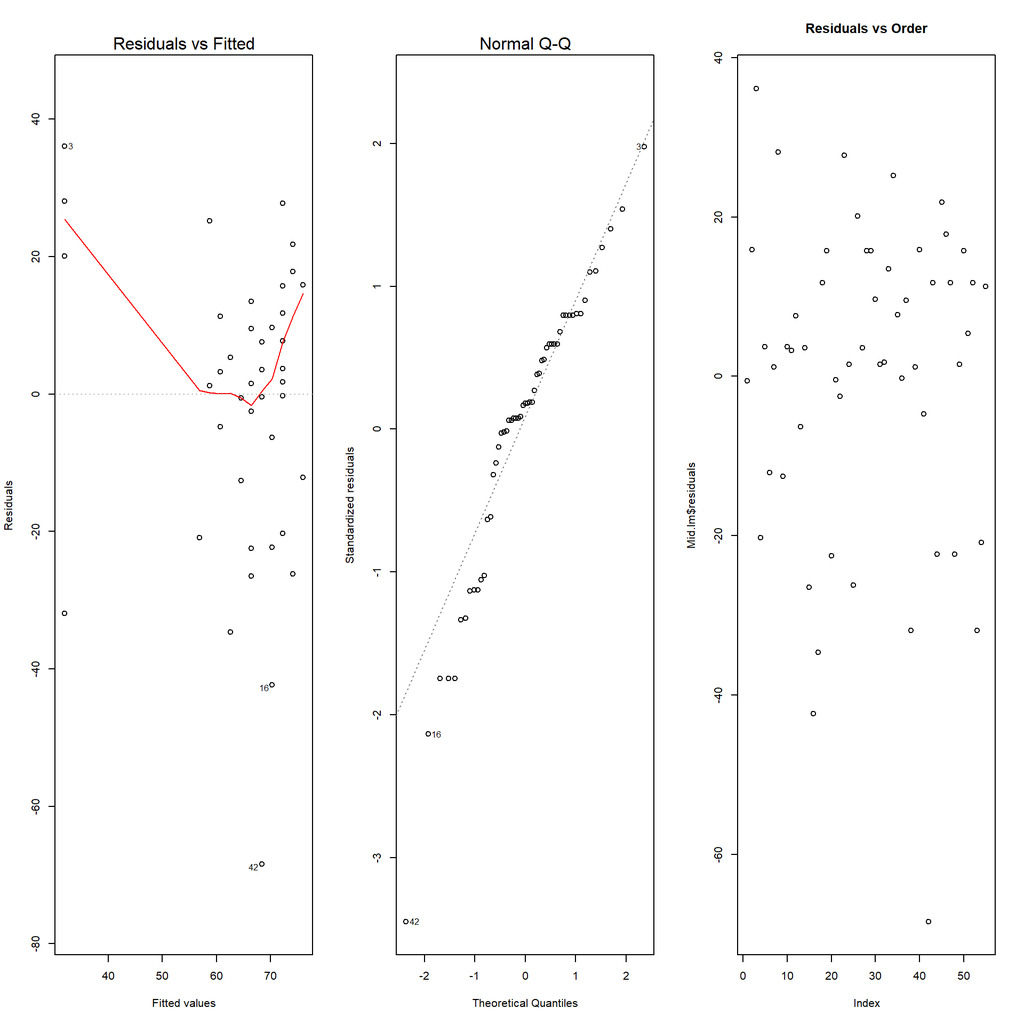

```r
#pairs(cbind(R = Mid.rem.lm$res, Fit = Mid.rem.lm$fit, Midterm_0_removed), panel = panel.smooth, pch=16, cex=0.7, col="black")

# Check Your Assumptions
par(mfrow=c(1,3))
plot(Mid.lm, which=1:2)
plot(Mid.lm$residuals, main = "Residuals vs Order")
```

```r
#plot(Mid.lm, which = 1)
# qqPlot(Mid.lm$residuals, main = "Q-Q Plot of Residuals", id = FALSE)

# # Check Your Assumptions
# par(mfrow=c(1,3))
# plot(Mid.rem.lm, which=1:2)
# plot(Mid.rem.lm$residuals, type = "b", main = "Residuals vs Order")
# #plot(Mid.rem.lm, which = 1)
# # qqPlot(Mid.rem.lm$residuals, main = "Q-Q Plot of Residuals", id = FALSE)
```

Mid.rem.lm has `Midterm` with 0.000814, but the y is not significant. I think I’ll keep the zeros in then.

Assumptions: Surprisingly it appears that variance is okay, while linearity relation between x and y is not normal. The error terms are not normally distributed. I’m also not sure, but there may be a pattern to the error terms? Observation 42 was one that I thought to remove. Not sure if this is okay or not.

`AssessmentQuizActual`, `AnalysesTheory`, `ClassActivities`, `SkillQuizzes`, `Analyses86`, and `Overall` seem to be some of the biggest players. Of these I think that `AnalysesTheory` and `Overall` do the best in explaining things. Before I wrote things out though I did a lm() with `AssessmentQuizActual` and `AnalysesTheory`.

#### Attempt 3

```r
Mid3.lm <- lm(FinalExam ~ Midterm + AssessmentQuizActual + AnalysesTheory, data = Midterm2)
pander(summary(Mid3.lm))
```

|  | Estimate | Std. Error | t value | Pr(>\|t\|) |
| --- | --- | --- | --- | --- |
| **(Intercept)** | 7.897 | 9.393 | 0.8407 | 0.4044 |
| **Midterm** | 0.302 | 0.1082 | 2.791 | 0.007377 |
| **AssessmentQuizActual** | 0.2915 | 0.1284 | 2.27 | 0.02744 |
| **AnalysesTheory** | 0.2888 | 0.1095 | 2.639 | 0.01101 |

Fitting linear model: FinalExam ~ Midterm + AssessmentQuizActual + AnalysesTheory

| Observations | Residual Std. Error | $R^2$ | Adjusted $R^2$ |
| --- | --- | --- | --- |
| 55 | 17.69 | 0.4429 | 0.4101 |

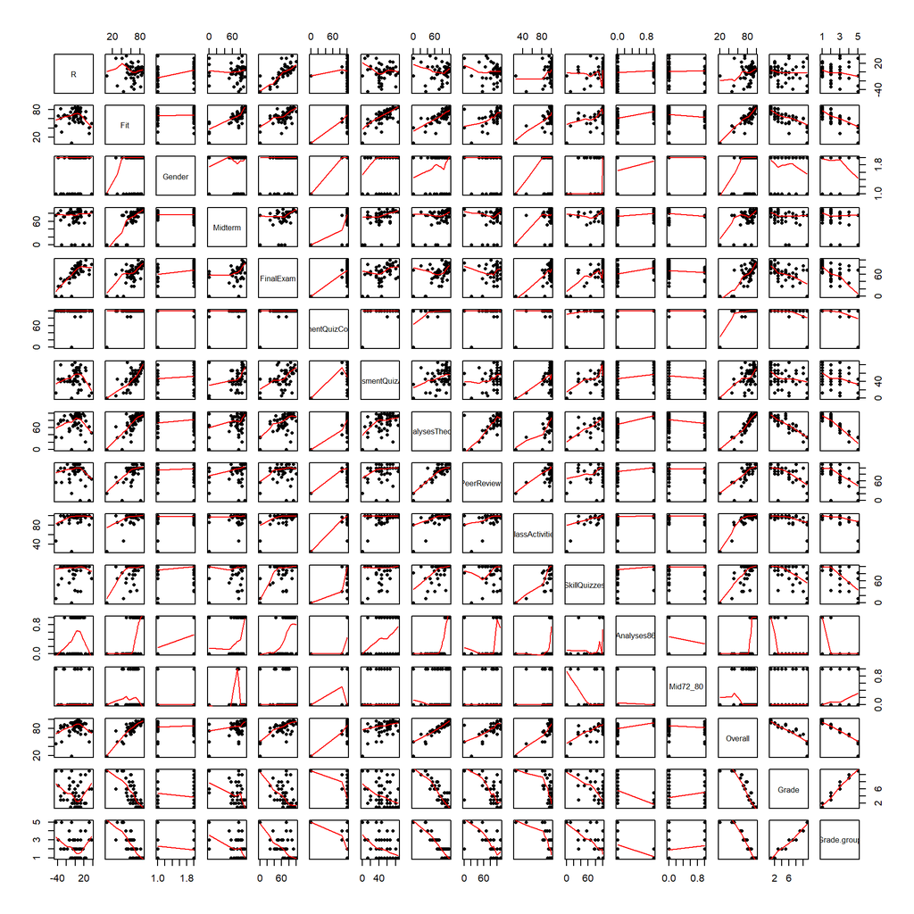

```r
pairs(cbind(R = Mid3.lm$res, Fit = Mid3.lm$fit, Midterm2), panel = panel.smooth, pch=16, cex=0.7, col="black")
```

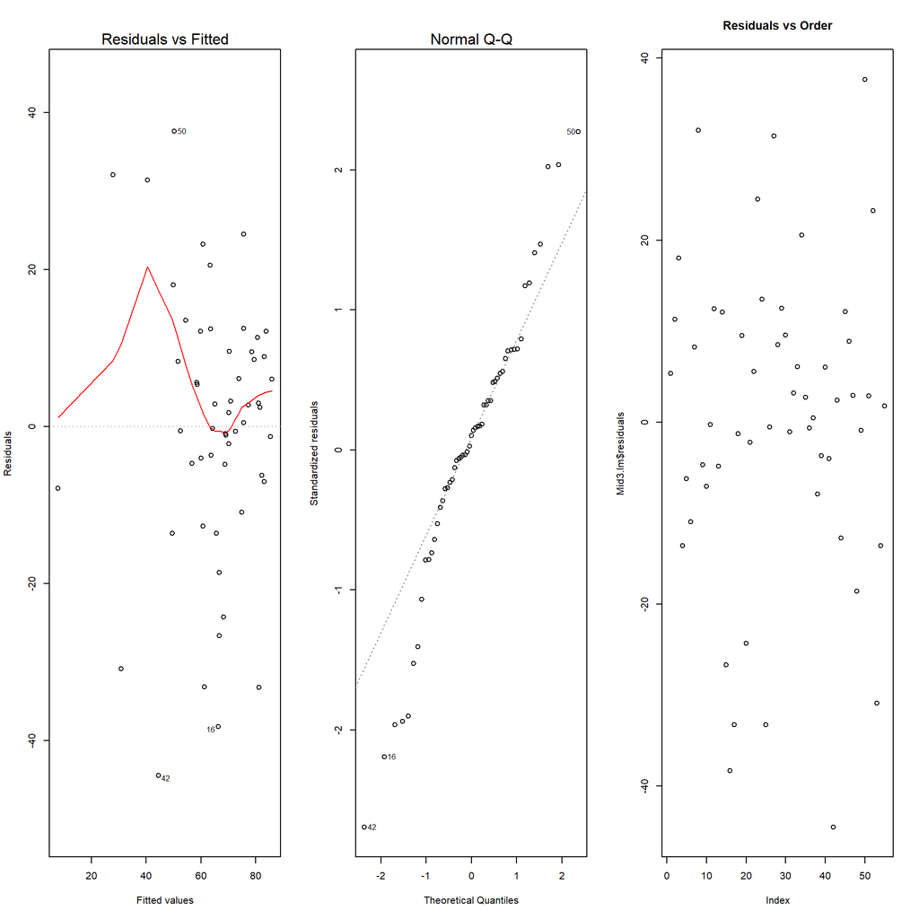

```r
# Check Your Assumptions
par(mfrow=c(1,3))
plot(Mid3.lm, which=1:2)
plot(Mid3.lm$residuals, main = "Residuals vs Order")
```

```r
#plot(Mid3.lm, which = 1)
# qqPlot(Mid3.lm$residuals, main = "Q-Q Plot of Residuals", id = FALSE)
```

Assumptions: Observation 50 is causing problems. Variance again seems normal. Linearity relation between x and y is not okay. Error terms are not distributed normally. Potential pattern again.

Pairs: I was thinking of adding `Overall` to this, but the more I think about it, I think I shouldn’t be using this column and my other other columns I created. I’ll need to ask Brother Saunders. I am going to try look at all of them and their interactions.

#### Attempt 4

```r
Mid4.lm <- lm(FinalExam ~ Midterm * AssessmentQuizActual * AnalysesTheory * ClassActivities * SkillQuizzes * Analyses86 * Overall, data = Midterm2)
pander(summary(Mid4.lm))

pairs(cbind(R = Mid4.lm$res, Fit = Mid4.lm$fit, Midterm2), panel = panel.smooth, pch=16, cex=0.7, col="black")

# Check Your Assumptions
par(mfrow=c(1,3))
plot(Mid4.lm, which=1:2)
plot(Mid4.lm$residuals, type = "b", main = "Residuals vs Order")
#plot(Mid4.lm, which = 1)
# qqPlot(Mid4.lm$residuals, main = "Q-Q Plot of Residuals", id = FALSE)
```

[output not shown]

Well that didn’t work. But I have an $R^2$ of 1! Haven’t seen that before. Let’s look at Attempt 2 again. I’m going to try `AnalysesTheory` and `Skillquizzes`.

#### Attempt 5

```r
Mid5.lm <- lm(FinalExam ~ Midterm + AnalysesTheory + SkillQuizzes, data = Midterm2)
pander(summary(Mid5.lm))
```

|  | Estimate | Std. Error | t value | Pr(>\|t\|) |
| --- | --- | --- | --- | --- |
| **(Intercept)** | -0.5871 | 10.2 | -0.05757 | 0.9543 |
| **Midterm** | 0.3549 | 0.1026 | 3.46 | 0.001102 |
| **AnalysesTheory** | 0.1713 | 0.1235 | 1.387 | 0.1716 |
| **SkillQuizzes** | 0.3271 | 0.1187 | 2.755 | 0.008117 |

Fitting linear model: FinalExam ~ Midterm + AnalysesTheory + SkillQuizzes

| Observations | Residual Std. Error | $R^2$ | Adjusted $R^2$ |
| --- | --- | --- | --- |
| 55 | 17.32 | 0.466 | 0.4346 |

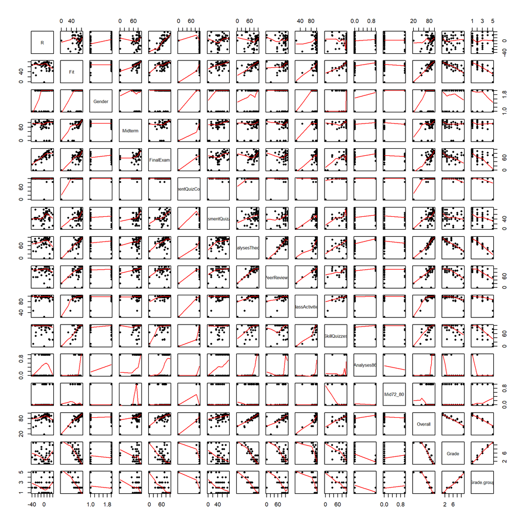

```r
pairs(cbind(R = Mid5.lm$res, Fit = Mid5.lm$fit, Midterm2), panel = panel.smooth, pch=16, cex=0.7, col="black")
```

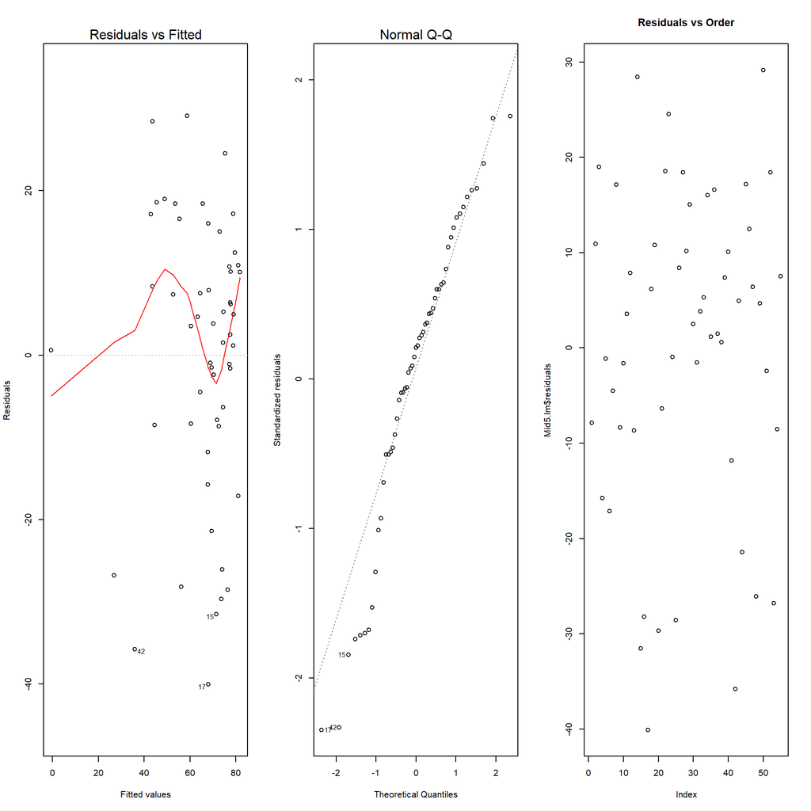

```r
# Check Your Assumptions
par(mfrow=c(1,3))
plot(Mid5.lm, which=1:2)
plot(Mid5.lm$residuals, main = "Residuals vs Order")
```

```r
#plot(Mid5.lm, which = 1)
# qqPlot(Mid5.lm$residuals, main = "Q-Q Plot of Residuals", id = FALSE)
```

I don’t know what I’m doing at this point. What happens if I add `Overall`?

#### Attempt 6

```r
Mid6.lm <- lm(FinalExam ~ Midterm + AnalysesTheory + SkillQuizzes + Overall, data = Midterm2)
pander(summary(Mid6.lm))
```

|  | Estimate | Std. Error | t value | Pr(>\|t\|) |
| --- | --- | --- | --- | --- |
| **(Intercept)** | -100.7 | 15.62 | -6.447 | 4.397e-08 |
| **Midterm** | -0.09049 | 0.09515 | -0.951 | 0.3462 |
| **AnalysesTheory** | -1.375 | 0.2312 | -5.949 | 2.631e-07 |
| **SkillQuizzes** | -0.2938 | 0.1201 | -2.446 | 0.01799 |
| **Overall** | 3.643 | 0.5043 | 7.224 | 2.68e-09 |

Fitting linear model: FinalExam ~ Midterm + AnalysesTheory + SkillQuizzes + Overall

| Observations | Residual Std. Error | $R^2$ | Adjusted $R^2$ |
| --- | --- | --- | --- |
| 55 | 12.23 | 0.7387 | 0.7178 |

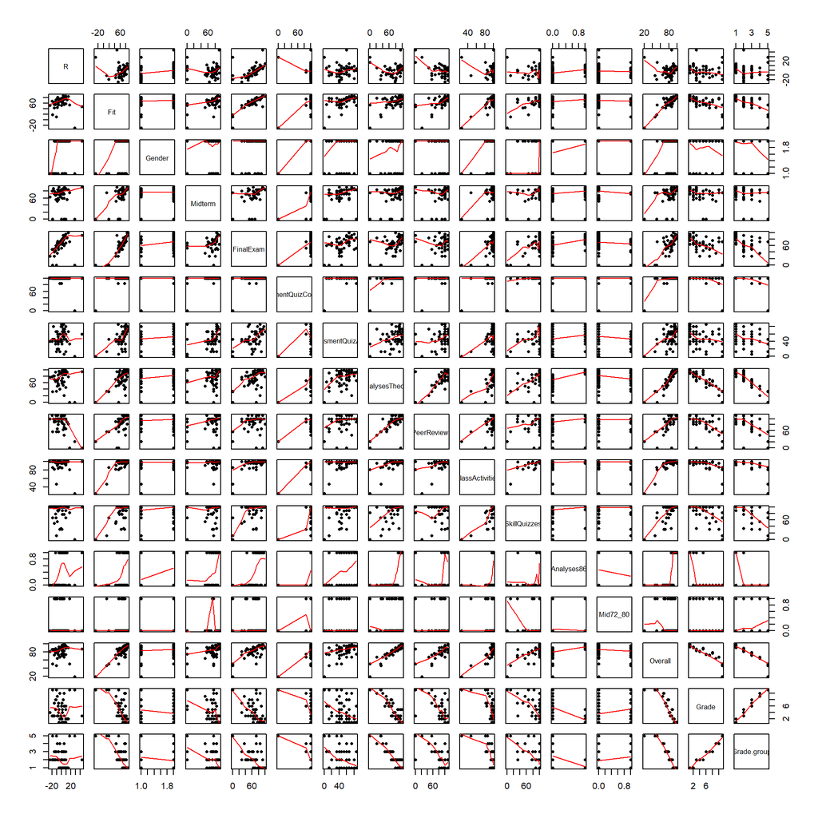

```r
pairs(cbind(R = Mid6.lm$res, Fit = Mid6.lm$fit, Midterm2), panel = panel.smooth, pch=16, cex=0.7, col="black")
```

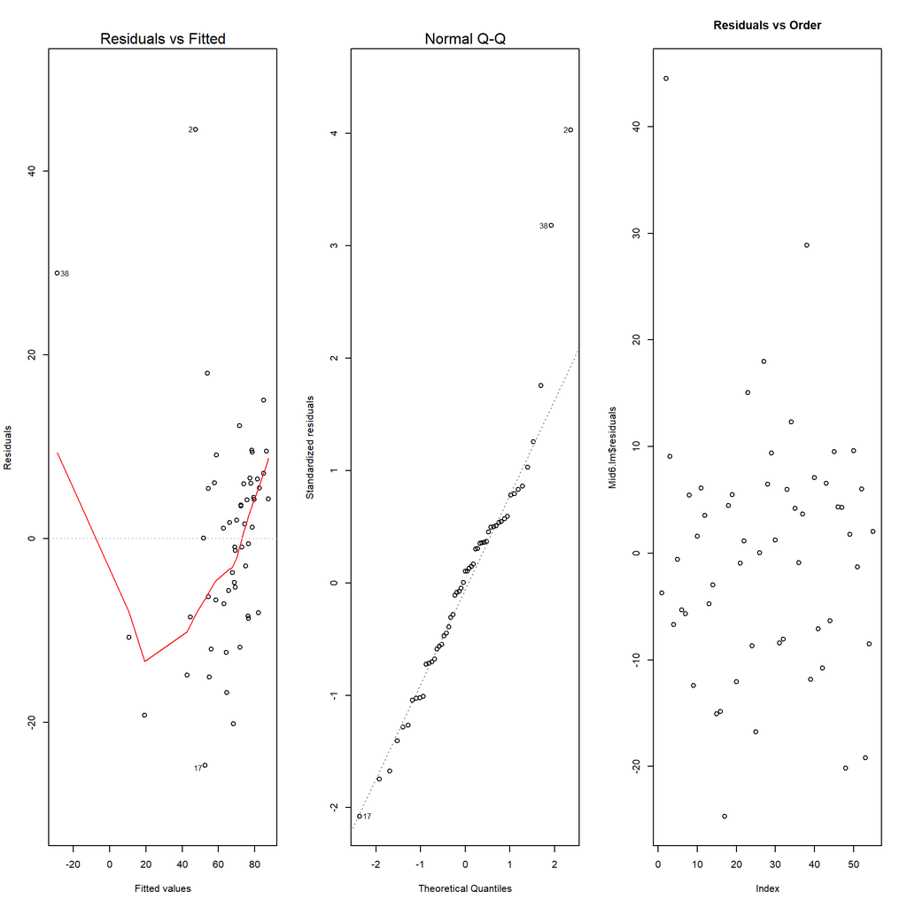

```r
# Check Your Assumptions
par(mfrow=c(1,3))
plot(Mid6.lm, which=1:2)
plot(Mid6.lm$residuals, main = "Residuals vs Order")
```

```r
#plot(Mid6.lm, which = 1)
# qqPlot(Mid6.lm$residuals, main = "Q-Q Plot of Residuals", id = FALSE)
```

Assumptions: Observation 38 seems to be problamatic. I’m going to remove it and see what happens.

#### Attempt 7

```r
mid2<- Midterm2[-38, ]

Mid7.lm <- lm(FinalExam ~ Midterm + AnalysesTheory + SkillQuizzes + Overall, data = mid2)
pander(summary(Mid7.lm))
```

|  | Estimate | Std. Error | t value | Pr(>\|t\|) |
| --- | --- | --- | --- | --- |
| **(Intercept)** | -137.9 | 17.61 | -7.832 | 3.452e-10 |
| **Midterm** | -0.0947 | 0.08585 | -1.103 | 0.2754 |
| **AnalysesTheory** | -1.631 | 0.2209 | -7.386 | 1.68e-09 |
| **SkillQuizzes** | -0.3095 | 0.1085 | -2.854 | 0.006312 |
| **Overall** | 4.334 | 0.4955 | 8.747 | 1.407e-11 |

Fitting linear model: FinalExam ~ Midterm + AnalysesTheory + SkillQuizzes + Overall

| Observations | Residual Std. Error | $R^2$ | Adjusted $R^2$ |
| --- | --- | --- | --- |
| 54 | 11.04 | 0.7543 | 0.7343 |

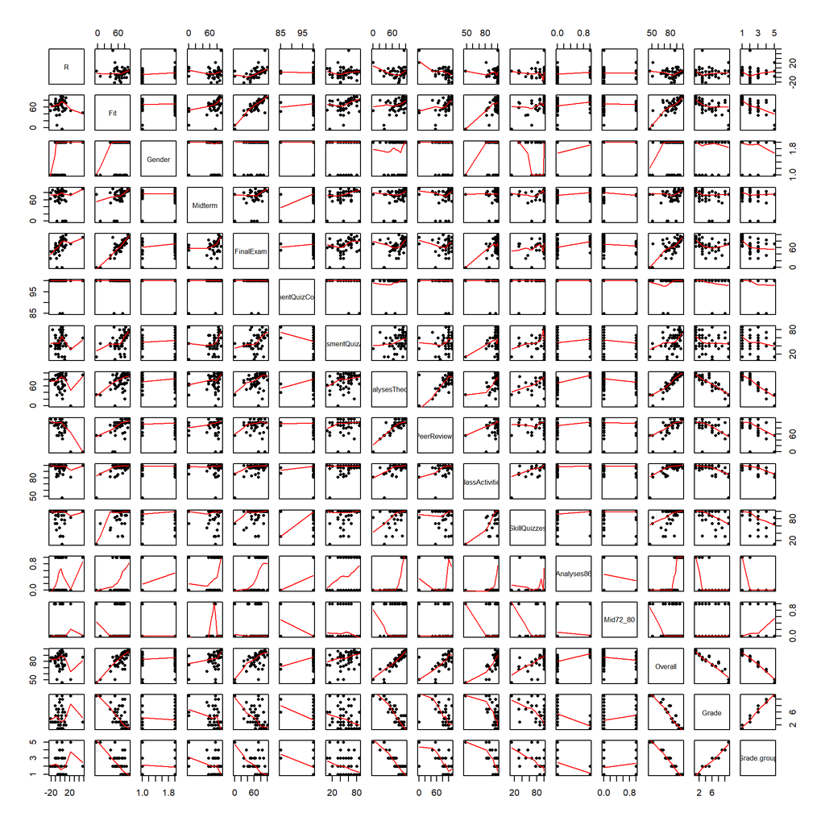

```r
pairs(cbind(R = Mid7.lm$res, Fit = Mid7.lm$fit, mid2), panel = panel.smooth, pch=16, cex=0.7, col="black")
```

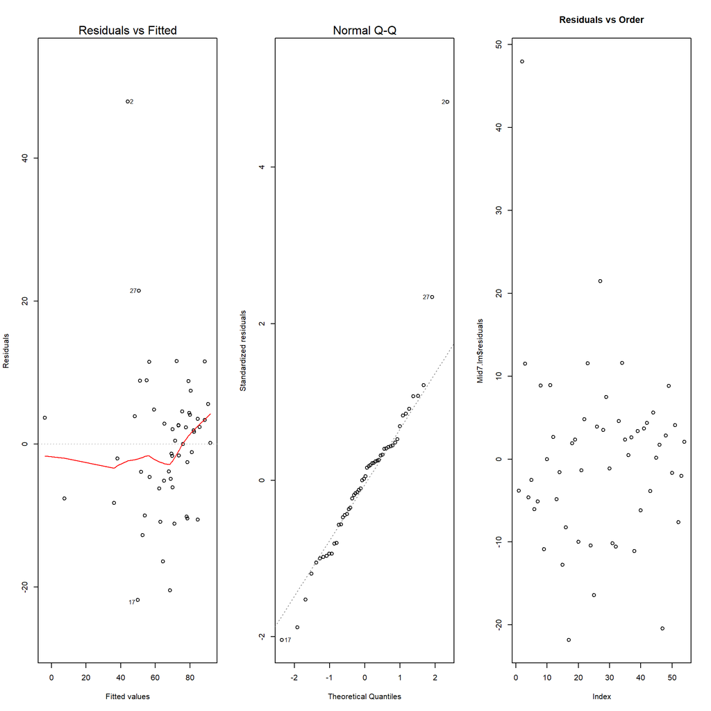

```r
# Check Your Assumptions
par(mfrow=c(1,3))
plot(Mid7.lm, which=1:2)
plot(Mid7.lm$residuals, main = "Residuals vs Order")
```

```r
#plot(Mid7.lm, which = 1)
# qqPlot(Mid7.lm$residuals, main = "Q-Q Plot of Residuals", id = FALSE)
```

I first removed observation 38, but then observation 2 looks bad too. SO let’s see.

#### Attempt 8

```r
mid3 <- Midterm2[c(-38, -2), ]

Mid8.lm <- lm(FinalExam ~ Midterm + AnalysesTheory + SkillQuizzes + Overall, data = mid3)
pander(summary(Mid8.lm))
```

|  | Estimate | Std. Error | t value | Pr(>\|t\|) |
| --- | --- | --- | --- | --- |
| **(Intercept)** | -165.1 | 13.51 | -12.22 | 2.387e-16 |
| **Midterm** | -0.2423 | 0.06659 | -3.638 | 0.0006697 |
| **AnalysesTheory** | -2.087 | 0.1755 | -11.89 | 6.482e-16 |
| **SkillQuizzes** | -0.4726 | 0.083 | -5.694 | 7.338e-07 |
| **Overall** | 5.358 | 0.3938 | 13.61 | 4.302e-18 |

Fitting linear model: FinalExam ~ Midterm + AnalysesTheory + SkillQuizzes + Overall

| Observations | Residual Std. Error | $R^2$ | Adjusted $R^2$ |
| --- | --- | --- | --- |
| 53 | 8.065 | 0.8679 | 0.8569 |

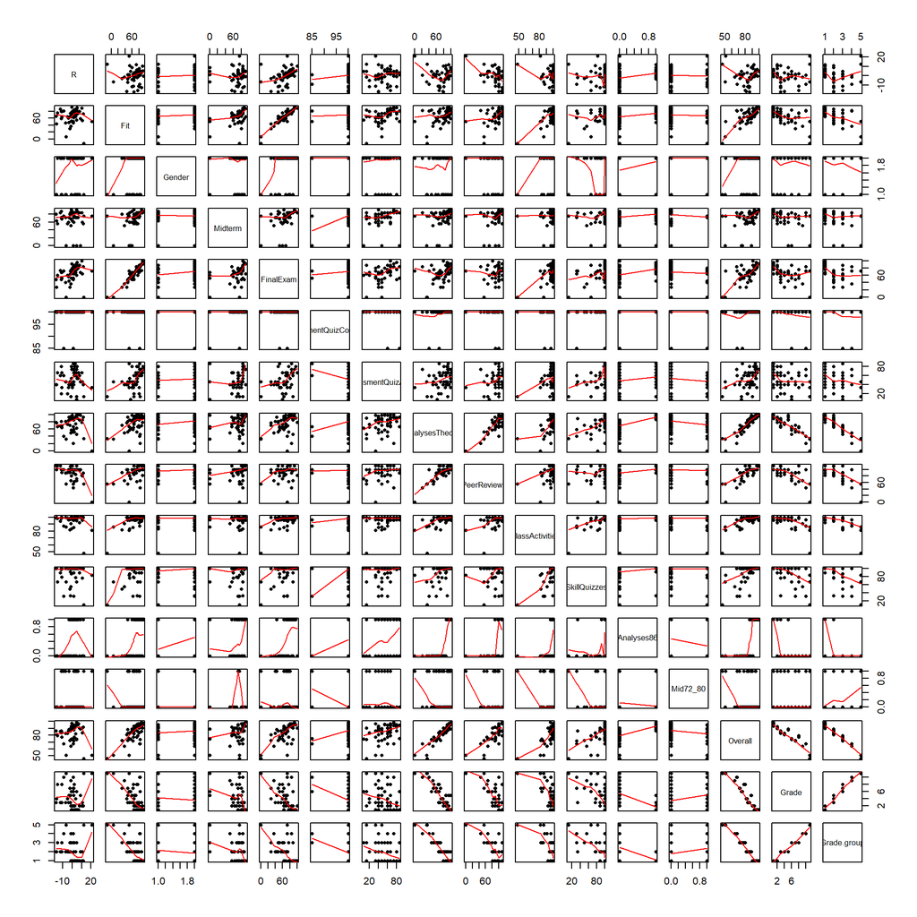

```r
pairs(cbind(R = Mid8.lm$res, Fit = Mid8.lm$fit, mid3), panel = panel.smooth, pch=16, cex=0.7, col="black")
```

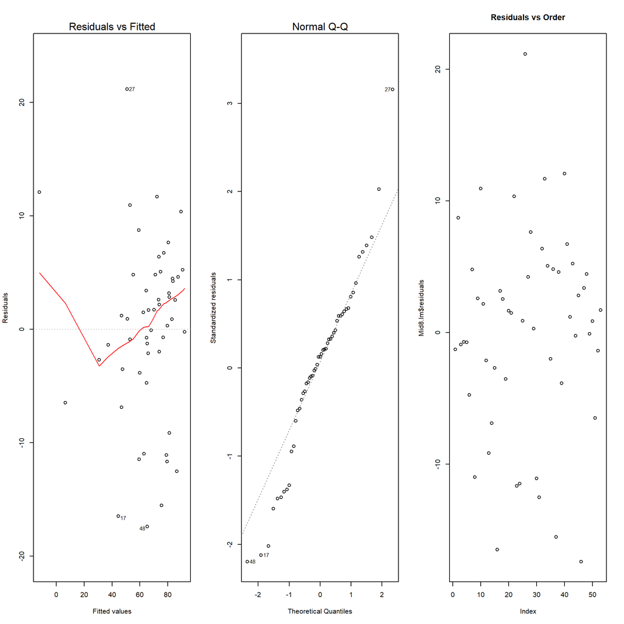

```r
# Check Your Assumptions
par(mfrow=c(1,3))
plot(Mid8.lm, which=1:2)
plot(Mid8.lm$residuals, main = "Residuals vs Order")
```

```r
#plot(Mid8.lm, which = 1)
# qqPlot(Mid8.lm$residuals, main = "Q-Q Plot of Residuals", id = FALSE)
```

$$\underbrace{\hat{Y_i}}_\text{Average Final Score} = -165.1 + -0.2423 \underbrace{X_{1i}}_\text{Midterm} + -2.087 \underbrace{X_{2i}}_\text{AnalysesTheory} + -0.4726 \underbrace{X_{3i}}_\text{SkillQuizzes} + 5.358 \underbrace{X_{4i}}_\text{Overall}$$

#### Attempt 9

I realized when writing out that model that I can’t control what my overall amount will be in order to predict my `Final` exam score. So I am going to look at Attempt 2 again, see what looks good, decide what I can control, and do that model.

It looks like the AnalysesTheory and ClassActivities all look promising. I am going to try that first.

```r
Mid9.lm <- lm(FinalExam ~ Midterm + AnalysesTheory + ClassActivities, data = Midterm2)
pander(summary(Mid9.lm))
```

|  | Estimate | Std. Error | t value | Pr(>\|t\|) |
| --- | --- | --- | --- | --- |
| **(Intercept)** | -42.99 | 18.18 | -2.365 | 0.02186 |
| **Midterm** | 0.3199 | 0.09951 | 3.215 | 0.002268 |
| **AnalysesTheory** | 0.08423 | 0.1266 | 0.6655 | 0.5087 |
| **ClassActivities** | 0.845 | 0.2418 | 3.495 | 0.0009907 |

Fitting linear model: FinalExam ~ Midterm + AnalysesTheory + ClassActivities

| Observations | Residual Std. Error | $R^2$ | Adjusted $R^2$ |
| --- | --- | --- | --- |
| 55 | 16.67 | 0.5051 | 0.476 |

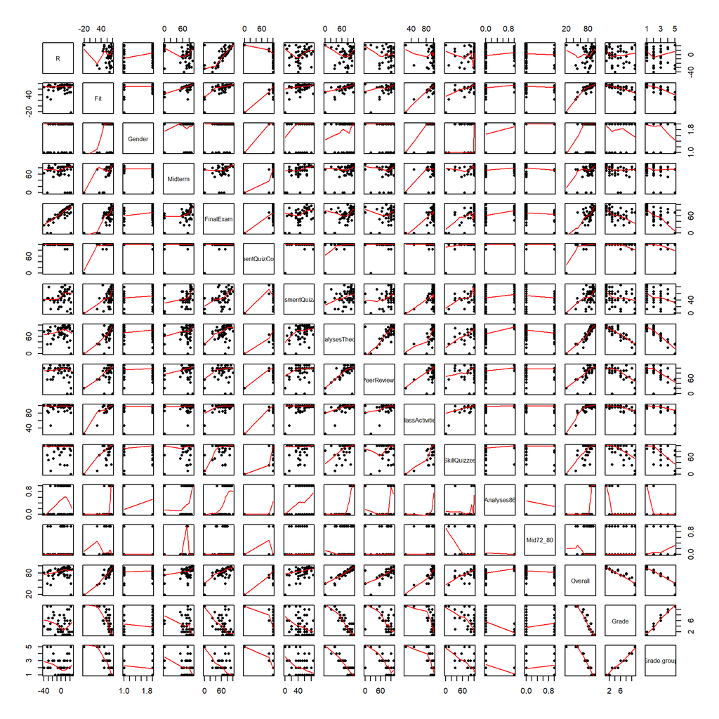

```r
pairs(cbind(R = Mid9.lm$res, Fit = Mid9.lm$fit, Midterm2), panel = panel.smooth, pch=16, cex=0.7, col="black")
```

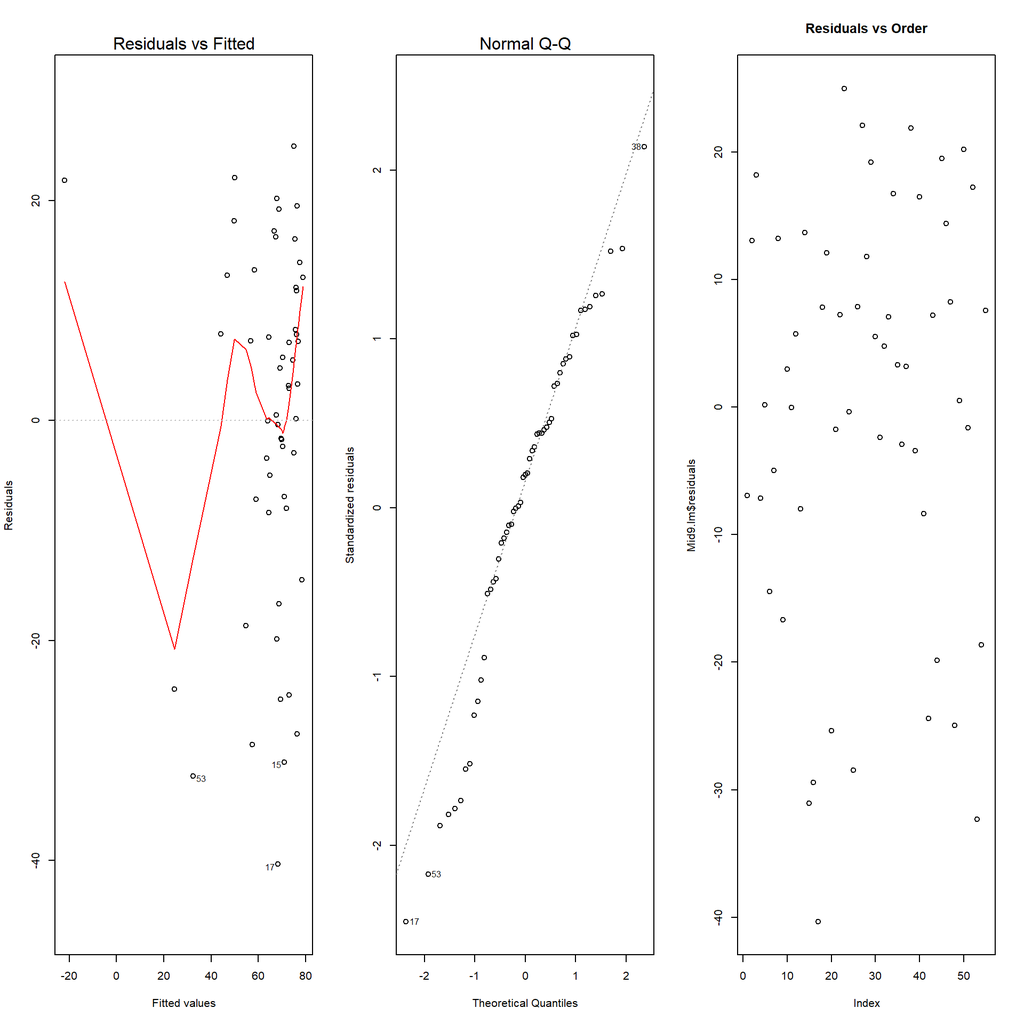

```r
#boxCox(Mid9.lm)

# Check Your Assumptions
par(mfrow=c(1,3))
plot(Mid9.lm, which=1:2)
plot(Mid9.lm$residuals, main = "Residuals vs Order")
```

```r
#plot(Mid9.lm, which = 1)
# qqPlot(Mid9.lm$residuals, main = "Q-Q Plot of Residuals", id = FALSE)
```

Do I need to do a transformation on `AnalysesTheory`? Not sure why this isn’t working. Also, the boxCox isn’t working because y is negative? Why? Do I just need to remove `AnalysesTheory`?

Assumptions: Does 53 need to be removed?

Pair: Do I need to combine `AssessmentQuizActual` and `ClassActivities`?

#### Attempt 10

```r
Mid10.lm <- lm(FinalExam ~ Midterm + AssessmentQuizActual + ClassActivities, data = Midterm2)
pander(summary(Mid10.lm))
```

|  | Estimate | Std. Error | t value | Pr(>\|t\|) |
| --- | --- | --- | --- | --- |
| **(Intercept)** | -43.06 | 16.93 | -2.544 | 0.01404 |
| **Midterm** | 0.2902 | 0.09879 | 2.938 | 0.004953 |
| **AssessmentQuizActual** | 0.2061 | 0.1215 | 1.697 | 0.09577 |
| **ClassActivities** | 0.8237 | 0.1978 | 4.164 | 0.0001205 |

Fitting linear model: FinalExam ~ Midterm + AssessmentQuizActual + ClassActivities

| Observations | Residual Std. Error | $R^2$ | Adjusted $R^2$ |
| --- | --- | --- | --- |
| 55 | 16.29 | 0.5275 | 0.4997 |

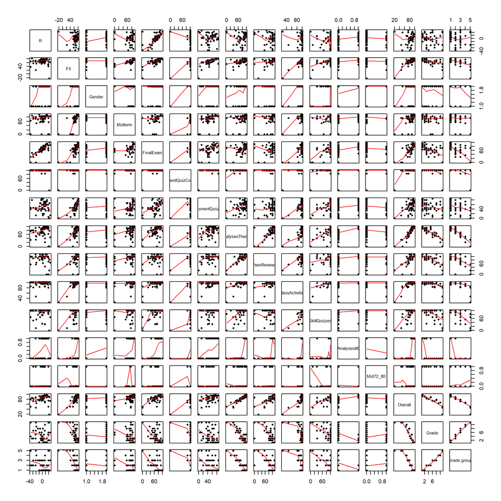

```r
pairs(cbind(R = Mid10.lm$res, Fit = Mid10.lm$fit, Midterm2), panel = panel.smooth, pch=16, cex=0.7, col="black")
```

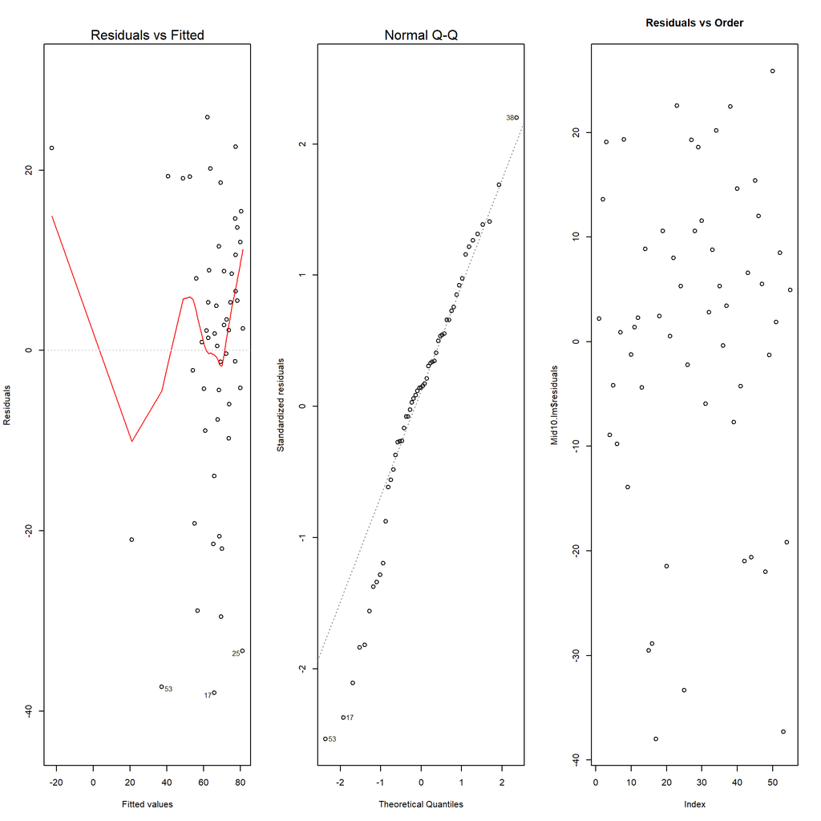

```r
#boxCox(Mid10.lm)

# Check Your Assumptions
par(mfrow=c(1,3))
plot(Mid10.lm, which=1:2)
plot(Mid10.lm$residuals, main = "Residuals vs Order")
```

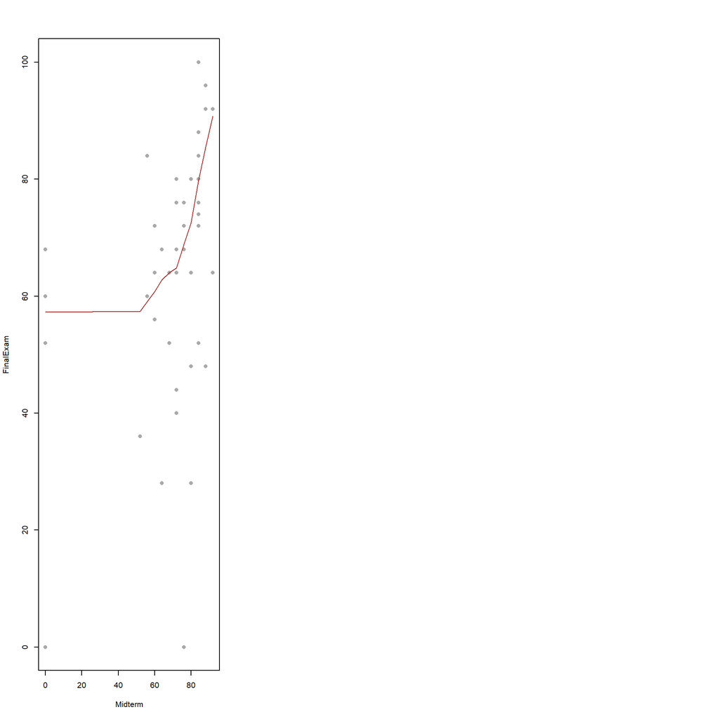

```r
#plot(Mid10.lm, which = 1)
# qqPlot(Mid10.lm$residuals, main = "Q-Q Plot of Residuals", id = FALSE)

plot(FinalExam ~ Midterm, data=Midterm2, pch=16, col="darkgray")
lines(lowess(Midterm2$Midterm, Midterm2$FinalExam), col="firebrick")
```

```r
Mid10.a.lm <- lm(FinalExam ~ Midterm + ClassActivities, data = Midterm2)
pander(summary(Mid10.a.lm))
```

|  | Estimate | Std. Error | t value | Pr(>\|t\|) |
| --- | --- | --- | --- | --- |
| **(Intercept)** | -46.97 | 17.07 | -2.751 | 0.008153 |
| **Midterm** | 0.3312 | 0.09751 | 3.396 | 0.001316 |
| **ClassActivities** | 0.9456 | 0.1876 | 5.04 | 5.978e-06 |

Fitting linear model: FinalExam ~ Midterm + ClassActivities

| Observations | Residual Std. Error | $R^2$ | Adjusted $R^2$ |
| --- | --- | --- | --- |
| 55 | 16.58 | 0.5008 | 0.4816 |

I’m going to go with this model for something to show.

#### Attempt 11

```r
Mid.0 <- Midterm_0_removed %>%
  select(c(-Analyses86, -Mid72_80, -Overall, -Grade, -Grade.group)) %>% view()

Mid.rem.lm <- lm(FinalExam ~ Midterm, data = Mid.0)
pander(summary(Mid.rem.lm))
```

|  | Estimate | Std. Error | t value | Pr(>\|t\|) |
| --- | --- | --- | --- | --- |
| **(Intercept)** | 10.76 | 16.59 | 0.6485 | 0.5198 |
| **Midterm** | 0.77 | 0.2151 | 3.579 | 0.000814 |

Fitting linear model: FinalExam ~ Midterm

| Observations | Residual Std. Error | $R^2$ | Adjusted $R^2$ |
| --- | --- | --- | --- |
| 49 | 15.69 | 0.2141 | 0.1974 |

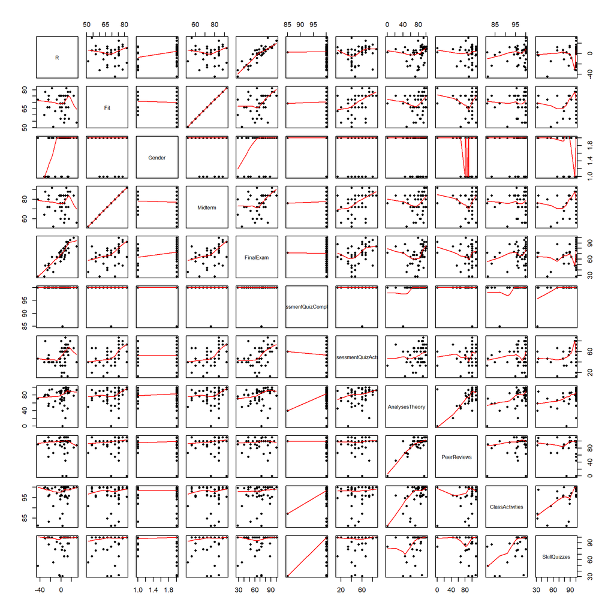

```r
pairs(cbind(R = Mid.rem.lm$res, Fit = Mid.rem.lm$fit, Mid.0), panel = panel.smooth, pch=16, cex=0.7, col="black")
```

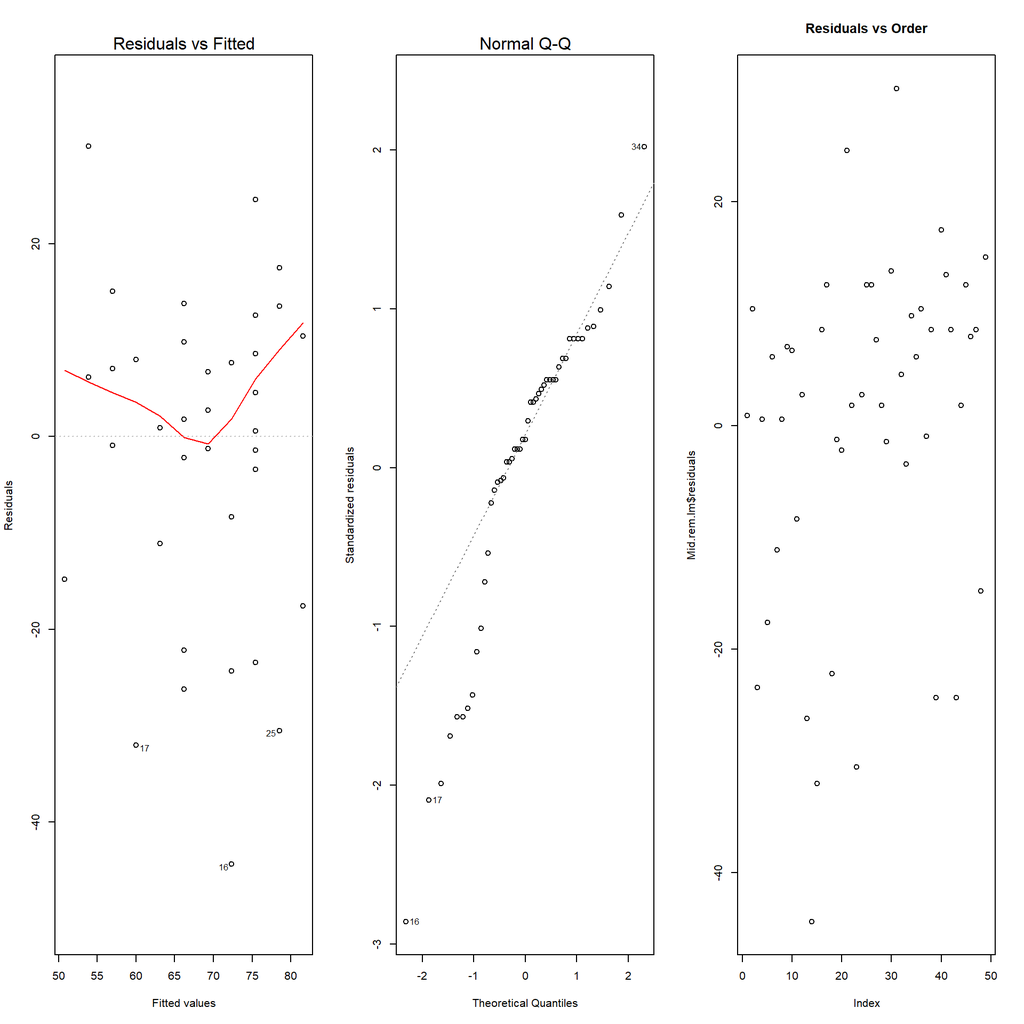

```r
# Check Your Assumptions
par(mfrow=c(1,3))
plot(Mid.rem.lm, which=1:2)
plot(Mid.rem.lm$residuals, main = "Residuals vs Order")
```

```r
#plot(Mid.rem.lm, which = 1)
# qqPlot(Mid.rem.lm$residuals, main = "Q-Q Plot of Residuals", id = FALSE)
```

This seems to be much better. I’m going to run this on `AssessmentQuizActual` and `AnalysesTheory`.

#### Attempt 12

```r
Mid.12.lm <- lm(FinalExam ~ Midterm + AssessmentQuizActual + AnalysesTheory, data = Mid.0)
pander(summary(Mid.12.lm))
```

|  | Estimate | Std. Error | t value | Pr(>\|t\|) |
| --- | --- | --- | --- | --- |
| **(Intercept)** | 6.843 | 17.36 | 0.3942 | 0.6953 |
| **Midterm** | 0.563 | 0.2367 | 2.379 | 0.02168 |
| **AssessmentQuizActual** | 0.2235 | 0.1384 | 1.615 | 0.1133 |
| **AnalysesTheory** | 0.1017 | 0.1075 | 0.9461 | 0.3491 |

Fitting linear model: FinalExam ~ Midterm + AssessmentQuizActual + AnalysesTheory

| Observations | Residual Std. Error | $R^2$ | Adjusted $R^2$ |
| --- | --- | --- | --- |
| 49 | 15.35 | 0.2805 | 0.2325 |

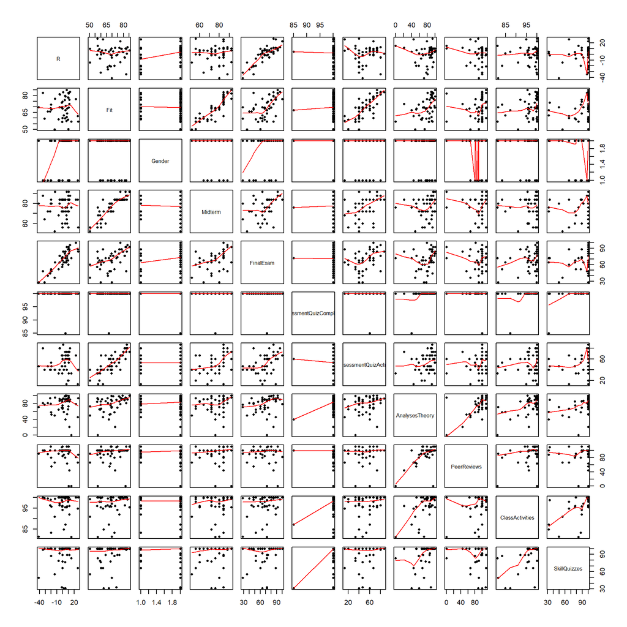

```r
pairs(cbind(R = Mid.12.lm$res, Fit = Mid.12.lm$fit, Mid.0), panel = panel.smooth, pch=16, cex=0.7, col="black")
```

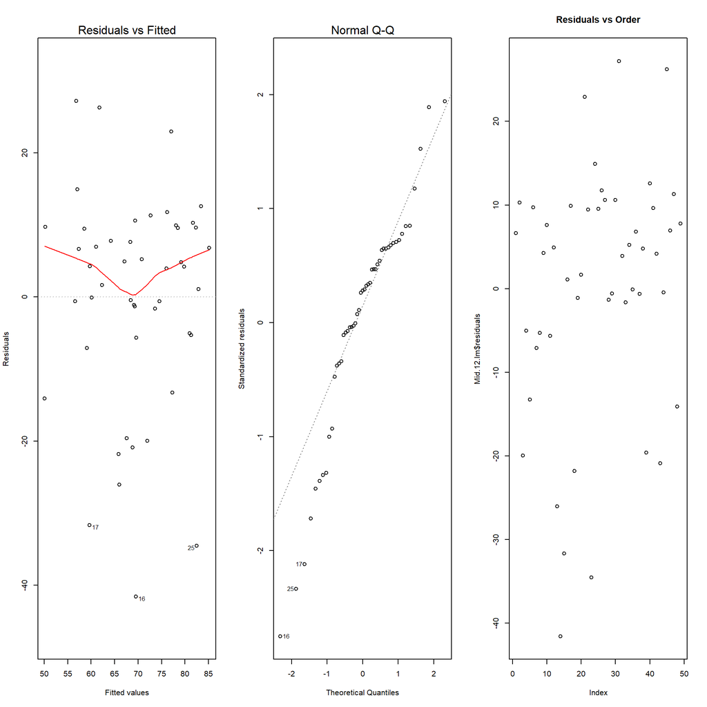

```r
# Check Your Assumptions
par(mfrow=c(1,3))
plot(Mid.12.lm, which=1:2)
plot(Mid.12.lm$residuals, main = "Residuals vs Order")
```

```r
#plot(Mid.12.lm, which = 1)
# qqPlot(Mid.12.lm$residuals, main = "Q-Q Plot of Residuals", id = FALSE)
```

I give up. I don’t know what to do at this point.

### Data

This data was provided to me by Brother Saunders. As a reminder, by downloading and using this data I have agreed to:

1. Keep the raw data confidential (though I can share my analysis of the data with others)
2. Not try to retrace any of the data to the original individuals in order to protect their rights and privacy.

```r
datatable(Midterm)
```

|  | Gender | Midterm | FinalExam | AssessmentQuizCompletion | AssessmentQuizActual | AnalysesTheory | PeerReviews | ClassActivities | SkillQuizzes |
| --- | --- | --- | --- | --- | --- | --- | --- | --- | --- |
| 1 | Male | 68 | 64 | 100 | 13.33 | 91.15 | 100 | 100 | 100 |
| 2 | Male | 92 | 92 | 100 | 60 | 95.2 |  | 100 | 100 |
| 3 | Male |  | 68 | 100 | 46.67 | 98.58 | 100 | 100 | 100 |
| 4 | Female | 84 | 52 | 100 | 53.33 | 58.08 | 80 | 83.27 | 87.37 |
| 5 | Male | 84 | 76 | 100 | 80 | 88.69 | 100 | 100 | 100 |
| 6 | Male | 92 | 64 | 100 | 40 | 95.5 | 100 | 99.4 | 100 |
| 7 | Male | 56 | 60 | 100 | 20 | 73 | 90.91 | 99.28 | 100 |
| 8 | Male |  | 60 | 100 | 6.67 | 62.69 | 71.43 | 100 | 100 |
| 9 | Female | 68 | 52 | 100 | 33.33 | 64.23 | 90.91 | 100 | 78.95 |
| 10 | Female | 84 | 76 | 100 | 80 | 91.54 | 100 | 96.4 | 100 |

[output cut: 45 more lines]